# Collaborative Filtering System

While content-based system relie (as the name suggests) on the content of the movies, collaborative systems relie on human interactions with the movies. Collaborative-filtering systems can use user informations to compare the user to other users with similarity metrics. Recommendations then are made based on what people who are similar to me like. The system that was developed here, however, is item based. Items are compared based on user feedback (e.g. reviews) with similarity metrics. Then, the items that are most closely related to the items that I like are recommended.

Let's discuss in more detail what such a system entails. To build our system, we used a dataset of critic reviews on Rotten Tomatoes (from Kaggle: https://www.kaggle.com/datasets/talha002/rottentomatoes-400k-review). We proceeded in the following steps:

1. **Reviewer-Movie-Matrix:** The columns are the reviewers and the rows the movies. Each entry tells us what score the reviewer gave the movie (if any). If the reviewer did not write a review of a specific movie, we set the value to 0. (Most entries are zero, we say the matrix is sparse.)
2. **Movie-Similarity-Matrix:** The Reviewer-Movie-Matrix gives us a vector of scores for each movie. We compare these vectors pairwise (here we use cosine similarity, but other metrics are possible) and create a new matrix that consists of these pairwise comparisons. The entries of this matrix tell us how similar each movie is to the other movies.
3. **Recommendations:** When the user provides their favorite movies, the system checks the Movie-Similarity-Matrix and finds the movies that are closest to them by adding the cosine similarity between that movie and each of the favorite movies.

## Data Download

The first step for any data related project is to find a dataset that can be used for the analysis. Here, we chose a dataset that contains of a large number of reviews from Rotten Tomatoes. Future work might involve building a new dataset that is more up to date. This dataset was last updated in 2022.

```python
# This Python 3 environment comes with many helpful analytics libraries installed
# It is defined by the kaggle/python Docker image: https://github.com/kaggle/docker-python
# For example, here's several helpful packages to load

import numpy as np # linear algebra
import pandas as pd # data processing, CSV file I/O (e.g. pd.read_csv)
import matplotlib.pyplot as plt
import seaborn as sns
from matplotlib import colormaps

# Input data files are available in the read-only "../input/" directory
# For example, running this (by clicking run or pressing Shift+Enter) will list all files under the input directory

import os
for dirname, _, filenames in os.walk('/kaggle/input'):
    for filename in filenames:
        print(os.path.join(dirname, filename))

# You can write up to 20GB to the current directory (/kaggle/working/) that gets preserved as output when you create a version using "Save & Run All"
# You can also write temporary files to /kaggle/temp/, but they won't be saved outside of the current session
```

```
/kaggle/input/rottentomatoes-400k-review/rottentomatoes-400k.csv
```

```python
# Build dataframe
df_reviews = pd.read_csv('/kaggle/input/rottentomatoes-400k-review/rottentomatoes-400k.csv')
```

We begin with some exploratory analysis of the data to get an overview and a better understanding of the dataset.

```python
# Check the first few entries
df_reviews.head(5)
```

|  | Unnamed: 0 | Movie | Reviewer | Publish | Review | Date | Score |
| --- | --- | --- | --- | --- | --- | --- | --- |
| 0 | 0 | HOTEL TRANSYLVANIA: TRANSFORMANIA | James Luxford | City AM | I guess its always been hard for me to see the... | 03/03/2022 | 40.0 |
| 1 | 1 | HOTEL TRANSYLVANIA: TRANSFORMANIA | Mat Brunet | AniMat's Review (YouTube) | Hotel Transylvania: Transformania is a present... | 15/02/2022 | 30.0 |
| 2 | 2 | HOTEL TRANSYLVANIA: TRANSFORMANIA | Robert Levin | Newsday | The conceit still works well enough to mostly ... | 29/01/2022 | 75.0 |
| 3 | 3 | HOTEL TRANSYLVANIA: TRANSFORMANIA | Jackie K. Cooper | jackiekcooper.com | No Adam Sandler this time out, but the animate... | 28/01/2022 | 60.0 |
| 4 | 4 | HOTEL TRANSYLVANIA: TRANSFORMANIA | Asher Luberto | The Playlist | It's not likely we'll see another one of these... | 28/01/2022 | 74.0 |

```python
# Check for nan values
df_reviews.isna().sum()
```

```
Unnamed: 0    0
Movie         0
Reviewer      0
Publish       0
Review        0
Date          0
Score         0
dtype: int64
```

```python
df_reviews['Movie'].unique()
```

```
array(['HOTEL TRANSYLVANIA: TRANSFORMANIA', 'SENSATION',
       'A COPS AND ROBBERS STORY', ..., 'REMEMBER THE DAZE',
       'HITLER: THE LAST TEN DAYS', 'THE ONE AND ONLY'], dtype=object)
```

```python
# Check the number of unique values for categorical input
columns_unique = ['Movie','Reviewer','Publish']
for column in columns_unique:
    print('The dataset has: ',df_reviews[column].nunique(),' unique values for ',column)
```

```
The dataset has:  9366  unique values for  Movie
The dataset has:  5736  unique values for  Reviewer
The dataset has:  1615  unique values for  Publish
```

```python
# Get info of data
df_reviews.info()
```

```
<class 'pandas.core.frame.DataFrame'>
RangeIndex: 417058 entries, 0 to 417057
Data columns (total 7 columns):
 #   Column      Non-Null Count   Dtype
---  ------      --------------   -----
 0   Unnamed: 0  417058 non-null  int64
 1   Movie       417058 non-null  object
 2   Reviewer    417058 non-null  object
 3   Publish     417058 non-null  object
 4   Review      417058 non-null  object
 5   Date        417058 non-null  object
 6   Score       417058 non-null  float64
dtypes: float64(1), int64(1), object(5)
memory usage: 22.3+ MB
```

## Data visualization

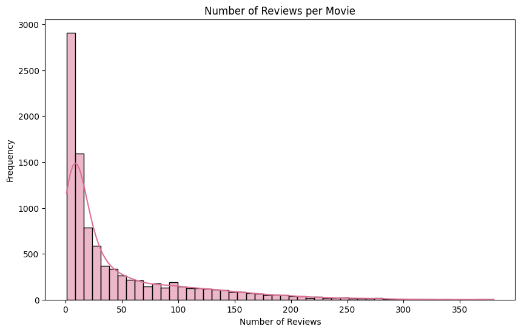

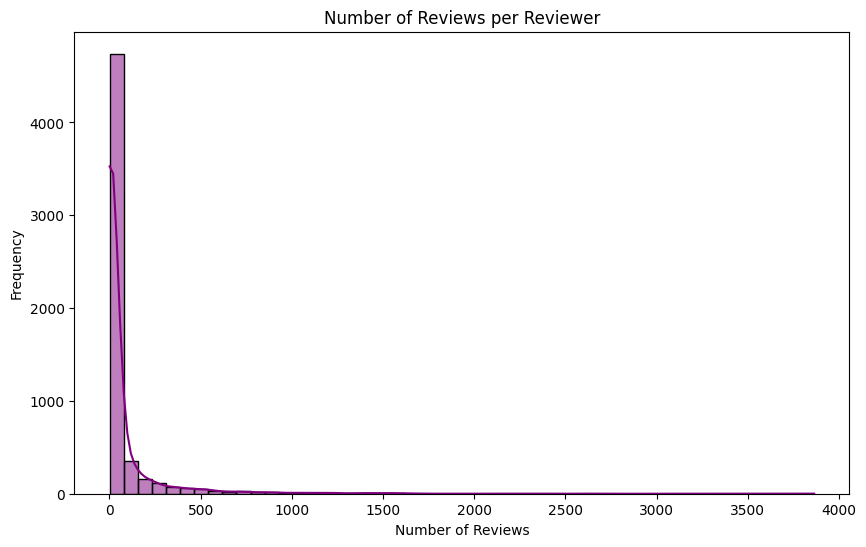

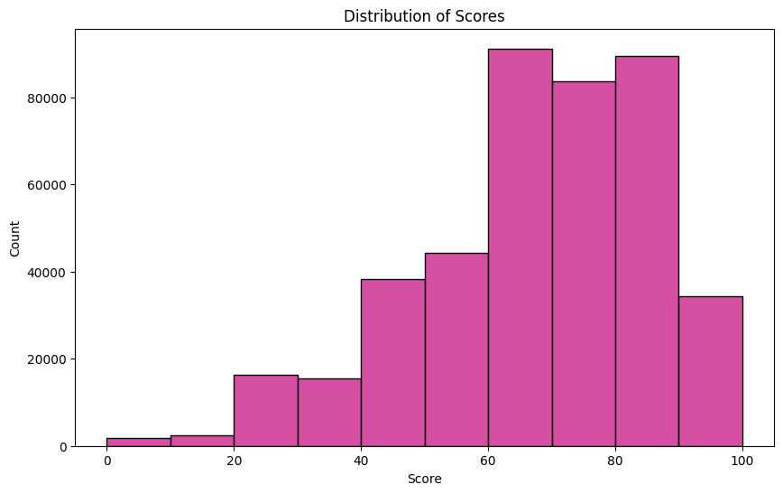

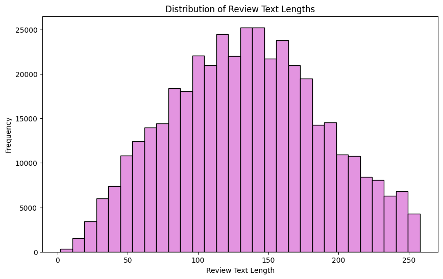

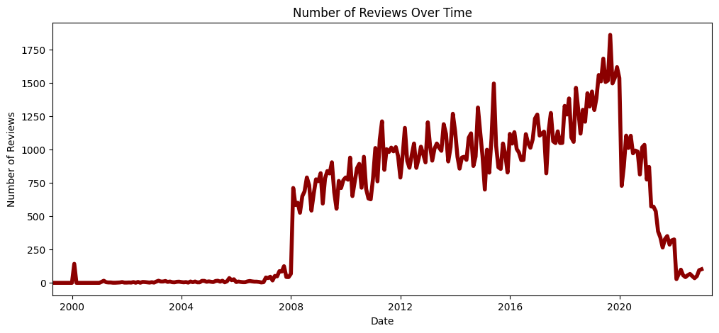

```python
# Number of reviews per movie
reviews_per_movie = df_reviews['Movie'].value_counts()

# Plot the distribution of the number of reviews per movie
plt.figure(figsize=(10, 6))
sns.histplot(reviews_per_movie, bins=50, kde=True, color='palevioletred')
plt.title('Number of Reviews per Movie')
plt.xlabel('Number of Reviews')
plt.ylabel('Frequency')
plt.show()

# Number of reviews per reviewer
reviews_per_reviewer = df_reviews['Reviewer'].value_counts()

# Plot the distribution of the number of reviews per reviewer
plt.figure(figsize=(10, 6))
sns.histplot(reviews_per_reviewer, bins=50, kde=True, color='purple')
plt.title('Number of Reviews per Reviewer')
plt.xlabel('Number of Reviews')
plt.ylabel('Frequency')
plt.show()

# Plot the distribution of scores
plt.figure(figsize=(10, 6))
sns.histplot(x='Score', data=df_reviews,bins=10,color='#C71585')
plt.title('Distribution of Scores')
plt.xlabel('Score')
plt.ylabel('Count')
plt.show()

# Length of the review texts
review_length = df_reviews['Review'].apply(len)

# Plot the distribution of review text lengths
plt.figure(figsize=(10, 6))
sns.histplot(review_length, bins=30, color='orchid')
plt.title('Distribution of Review Text Lengths')
plt.xlabel('Review Text Length')
plt.ylabel('Frequency')
plt.show()

# Dates of the reviews
df_reviews['Date_time'] = df_reviews['Date']
df_reviews['Date_time'] = pd.to_datetime(df_reviews['Date_time'],errors='coerce')

# Set 'Date' as the index
df_reviews.set_index('Date_time', inplace=True)

# Plot the number of reviews over time
plt.figure(figsize=(12, 5))
plt.plot(df_reviews.resample('M').size(),'-',color='darkred',linewidth=4)
plt.title('Number of Reviews Over Time')
plt.xlabel('Date')
plt.ylabel('Number of Reviews')
plt.xlim([10700,19500])
plt.show()
```

# Recommendation System -- Collaborative-Filtering

## Data Preparation

```python
# Drop unnecessary columns
df_reviews = df_reviews[['Movie', 'Reviewer', 'Score']]

# Pivot the table to get an item-user matrix
item_user_matrix = df_reviews.pivot_table(index='Movie', columns='Reviewer', values='Score')

# Display the matrix
item_user_matrix.head()
```

| Reviewer Movie | A.A. Dowd | A.H. Weiler | A.J. Serrano | A.O. Scott | A.S. Hamrah | AJ Caulfield | AP Kryza | Aaron Aradillas | Aaron Asadi | Aaron Barnhart | ... | Zhuo-Ning Su | Zoe Camp | Zoe Hewitt | Zoe Margolis | Zoe Rose Smith | Zofia Wijaszka | Zosia Bielski | tt stern-enzi | Álex Manzano | Álvaro de Luna |
| --- | --- | --- | --- | --- | --- | --- | --- | --- | --- | --- | --- | --- | --- | --- | --- | --- | --- | --- | --- | --- | --- |
| #HORROR | NaN | NaN | NaN | NaN | NaN | NaN | NaN | NaN | NaN | NaN | ... | NaN | NaN | NaN | NaN | NaN | NaN | NaN | NaN | NaN | NaN |
| #UNFIT: THE PSYCHOLOGY OF DONALD TRUMP | NaN | NaN | NaN | NaN | NaN | NaN | NaN | NaN | NaN | NaN | ... | NaN | NaN | NaN | NaN | NaN | NaN | NaN | NaN | NaN | NaN |
| $ (DOLLARS) | NaN | NaN | NaN | NaN | NaN | NaN | NaN | NaN | NaN | NaN | ... | NaN | NaN | NaN | NaN | NaN | NaN | NaN | NaN | NaN | NaN |
| $9.99 | NaN | NaN | NaN | 60.0 | NaN | NaN | NaN | NaN | NaN | NaN | ... | NaN | NaN | NaN | NaN | NaN | NaN | NaN | NaN | NaN | NaN |
| '71 | NaN | NaN | NaN | NaN | NaN | NaN | NaN | NaN | NaN | NaN | ... | NaN | NaN | NaN | NaN | NaN | NaN | NaN | NaN | NaN | NaN |

5 rows × 5736 columns

```python
item_user_matrix.notna().sum()/df_reviews['Movie'].nunique()
```

```
Reviewer
A.A. Dowd         0.068653
A.H. Weiler       0.000320
A.J. Serrano      0.000107
A.O. Scott        0.057122
A.S. Hamrah       0.000320
                    ...
Zofia Wijaszka    0.001388
Zosia Bielski     0.000214
tt stern-enzi     0.022849
Álex Manzano      0.000961
Álvaro de Luna    0.000107
Length: 5736, dtype: float64
```

## Similarity Matrix

We use the cosine similarity as a metric to make pairwise comparisons between all movies. This procedure uses the Item-User-Matrix to generate vectors for each movie. These vectors are compared to each other using cosine similarity.

```python
from sklearn.metrics.pairwise import cosine_similarity

# Fill NaN values with zeros
item_user_matrix_filled = item_user_matrix.fillna(0)

# Calculate item similarity using cosine similarity
item_similarity = cosine_similarity(item_user_matrix_filled)

# Convert the similarity matrix to a DataFrame for better visualization
item_similarity_df = pd.DataFrame(item_similarity, index=item_user_matrix_filled.index, columns=item_user_matrix_filled.index)

# Display the item similarity matrix (optional)
item_similarity_df.head(10)
```

| Movie | #HORROR | #UNFIT: THE PSYCHOLOGY OF DONALD TRUMP | $ (DOLLARS) | $9.99 | '71 | (500) DAYS OF SUMMER | (UNTITLED) | 09-Nov | 1 | 1 NIGHT | ... | ZIPPER | ZOMBEAVERS | ZOMBIE FOR SALE | ZOMBIE STRIPPERS | ZOMBIELAND: DOUBLE TAP | ZONE 414 - CITY OF ROBOTS | ZOO | ZOOLANDER NO. 2 | ZOOTOPIA | ÉVOCATEUR: THE MORTON DOWNEY JR. MOVIE |
| --- | --- | --- | --- | --- | --- | --- | --- | --- | --- | --- | --- | --- | --- | --- | --- | --- | --- | --- | --- | --- | --- |
| #HORROR | 1.000000 | 0.000000 | 0.000000 | 0.032437 | 0.039099 | 0.047614 | 0.000000 | 0.000000 | 0.405935 | 0.000000 | ... | 0.065048 | 0.062091 | 0.000000 | 0.000000 | 0.018949 | 0.000000 | 0.000000 | 0.093149 | 0.044378 | 0.000000 |
| #UNFIT: THE PSYCHOLOGY OF DONALD TRUMP | 0.000000 | 1.000000 | 0.000000 | 0.097919 | 0.083660 | 0.106924 | 0.058315 | 0.113559 | 0.000000 | 0.000000 | ... | 0.046803 | 0.056730 | 0.150876 | 0.061298 | 0.042114 | 0.074557 | 0.101571 | 0.015687 | 0.114422 | 0.000000 |
| $ (DOLLARS) | 0.000000 | 0.000000 | 1.000000 | 0.000000 | 0.000000 | 0.099121 | 0.141504 | 0.000000 | 0.000000 | 0.000000 | ... | 0.000000 | 0.000000 | 0.000000 | 0.000000 | 0.000000 | 0.000000 | 0.000000 | 0.000000 | 0.000000 | 0.000000 |
| $9.99 | 0.032437 | 0.097919 | 0.000000 | 1.000000 | 0.101038 | 0.199459 | 0.156492 | 0.077545 | 0.000000 | 0.000000 | ... | 0.000000 | 0.038739 | 0.000000 | 0.102332 | 0.000000 | 0.050913 | 0.047561 | 0.040277 | 0.058243 | 0.155277 |
| '71 | 0.039099 | 0.083660 | 0.000000 | 0.101038 | 1.000000 | 0.178260 | 0.179573 | 0.127329 | 0.014913 | 0.065815 | ... | 0.068347 | 0.105177 | 0.024743 | 0.113851 | 0.130649 | 0.102243 | 0.060536 | 0.222594 | 0.303599 | 0.060639 |
| (500) DAYS OF SUMMER | 0.047614 | 0.106924 | 0.099121 | 0.199459 | 0.178260 | 1.000000 | 0.155637 | 0.059985 | 0.051873 | 0.033971 | ... | 0.027666 | 0.112023 | 0.019395 | 0.253354 | 0.165544 | 0.097696 | 0.085888 | 0.195144 | 0.253720 | 0.155840 |
| (UNTITLED) | 0.000000 | 0.058315 | 0.141504 | 0.156492 | 0.179573 | 0.155637 | 1.000000 | 0.102177 | 0.000000 | 0.000000 | ... | 0.018253 | 0.076193 | 0.000000 | 0.213116 | 0.085911 | 0.098490 | 0.000000 | 0.120540 | 0.080145 | 0.050366 |
| 09-Nov | 0.000000 | 0.113559 | 0.000000 | 0.077545 | 0.127329 | 0.059985 | 0.102177 | 1.000000 | 0.000000 | 0.328358 | ... | 0.153552 | 0.196785 | 0.000000 | 0.161371 | 0.065275 | 0.258086 | 0.000000 | 0.186568 | 0.137830 | 0.000000 |
| 1 | 0.405935 | 0.000000 | 0.000000 | 0.000000 | 0.014913 | 0.051873 | 0.000000 | 0.000000 | 1.000000 | 0.000000 | ... | 0.069468 | 0.090979 | 0.000000 | 0.011106 | 0.042195 | 0.054467 | 0.000000 | 0.047538 | 0.068842 | 0.140306 |
| 1 NIGHT | 0.000000 | 0.000000 | 0.000000 | 0.000000 | 0.065815 | 0.033971 | 0.000000 | 0.328358 | 0.000000 | 1.000000 | ... | 0.182492 | 0.143867 | 0.000000 | 0.094531 | 0.044301 | 0.188437 | 0.000000 | 0.080282 | 0.039039 | 0.000000 |

10 rows × 9366 columns

## Movie Recommendations

Now that we have the similarity matrix, we can create a function that takes as input a set of movies with ratings and returns recommendations. In particular, the function takes as input the matrix that gives us the similarity of the movies as well as a set of movies and ratings. With the ratings as weights, it sums up the similarity values to find the movies that are most similar to the input movies. This function is used on the website for the collaborative filtering approach.

```python
def get_movie_recommendations(user_movies, item_similarity_matrix, user_ratings):
    # Create an empty DataFrame to store the recommendations
    recommendations = pd.DataFrame({'Movie': item_similarity_df.index,'Score': [0 for k in range(len(item_similarity_df.index))]})

    # Loop through each movie in the user's list
    for movie in user_movies:
        # Get the similarity scores between the current movie and all other movies
        similarity_scores = item_similarity_matrix[movie]

        # Multiply the similarity scores by the user's ratings
        weighted_scores = similarity_scores * user_ratings[movie]

        # Add the weighted scores to the recommendations DataFrame
        recommendations['Score'] += weighted_scores.values

    # Filter out movies the user has already watched
    recommendations = recommendations[~recommendations.Movie.isin(user_movies)]

    # Sort the recommendations by score in descending order
    recommendations = recommendations.sort_values(by='Score', ascending=False)[:5]


    return recommendations.Movie.tolist()
```

```python
user_movies = ['JOHN WICK', 'ARRIVAL', 'GUARDIANS OF THE GALAXY','ARTHUR CHRISTMAS','DAWN OF THE PLANET OF THE APES','ZOOTOPIA','INSIDE OUT','FROZEN']  # Replace with some movies you like
user_ratings = {'JOHN WICK':98, 'ARRIVAL':99, 'GUARDIANS OF THE GALAXY':91,'ARTHUR CHRISTMAS':89,'DAWN OF THE PLANET OF THE APES':85,'ZOOTOPIA':87,
                        'INSIDE OUT':92,'FROZEN':75}


# Example for the recommendations
recommendations = get_movie_recommendations(user_movies, item_similarity_df, user_ratings)

print(recommendations)
```

```
['INTERSTELLAR', 'GODZILLA', 'EDGE OF TOMORROW', 'JURASSIC WORLD', 'MAD MAX: FURY ROAD']
```

## Future Work - Collaborative Filtering

As mentioned before, this simple collaborative-filtering algorithm makes a strong assumption on the movies that have not been reviewed by a reviewer, namely that the reviewer does not like the movie. That is not necessarily the case.

So, we future work should build on another approach: **Matrix Factorization**. The idea behind this approach is to predict missing reviewer rating based on the review data. In particular, we build a machine learning model that learns lower-dimensional representations of the users and movies in a so called **embedding space**. The embeddings summarize the properties of the movies and reviewers and these properties are used to predict the missing ratings (as the dot products of the two embeddings). The model then minimizes the difference between predicted and actual ratings during training. By doing so, it learns patterns and relationships in the data, enabling it to make predictions for user-movie pairs it hasn't seen during training.

Due to the sparsity of this dataset, Matrix Factorization recommendation systems built upon this data set are not able to capture the specific features of the reviewers particularly well. So, implementing this approach on a new dataset is crucial to obtain relevant and personal movie recommendations.